# Spatial Transcriptomics - Seurat Analysis of Human Glioblastoma (GBM) FFPE Tissue

# Possible correlation

## Identification of Spatially Variable Features using Seurat

Perform differential expression based on pre-annotated anatomical regions within the tissue, which may be determined either from unsupervised clustering or prior knowledge.

Cluster 5 and 9 have ‘COL’ type genes overly expressed when compared to all other clusters

```r
avg_sct_residuals <- as.matrix(
  AverageExpression(
    GBM,
    assays = "SCT",
    group.by = "seurat_clusters",
    layer = "scale.data"
  )$SCT
)

rho <- cor(avg_sct_residuals, method = "spearman")
cor_5_9 <- rho["g5", "g9"]

matches_5 <- sort(
  rho["g5", colnames(rho) != "g5"],
  decreasing = TRUE
)

data.frame(
  rank = seq_along(matches_5),
  cluster = sub("^g", "", names(matches_5)),
  spearman_rho = round(unname(matches_5), 3)
)
```

| rank | cluster | spearman_rho |
| --- | --- | --- |
| 1 | 9 | 0.571 |
| 2 | 19 | 0.540 |
| 3 | 4 | 0.483 |
| 4 | 14 | 0.447 |
| 5 | 8 | 0.435 |
| 6 | 1 | 0.420 |
| 7 | 20 | 0.342 |
| 8 | 7 | 0.335 |
| 9 | 0 | 0.283 |
| 10 | 2 | 0.240 |

[output cut: 10 more lines]

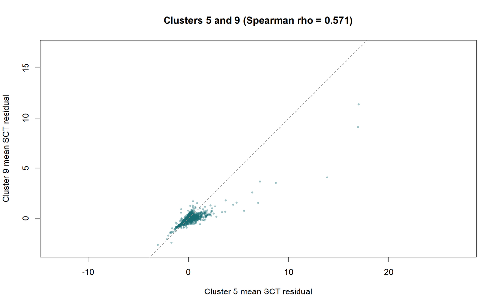

```r
pair <- avg_sct_residuals[, c("g5", "g9")]
limits <- range(pair)

plot(
  pair[, "g5"], pair[, "g9"],
  xlim = limits, ylim = limits, asp = 1,
  pch = 16, cex = 0.55,
  col = adjustcolor("#176C72", alpha.f = 0.4),
  xlab = "Cluster 5 mean SCT residual",
  ylab = "Cluster 9 mean SCT residual",
  main = sprintf("Clusters 5 and 9 (Spearman rho = %.3f)", cor_5_9)
)
abline(a = 0, b = 1, lty = 2, col = "grey55")
```

## Mapping the clusters and gene programms

This highlights clusters 5 (Collagen), 9 (Collagen) and 7 (Hypoxia) on the same H&E image.

```r
focus <- c("5", "9", "7")
cluster <- as.character(GBM$seurat_clusters)
GBM$focus_region <- factor(
  ifelse(cluster %in% focus, cluster, "Other"),
  levels = c(focus, "Other")
)

p_clusters <- SpatialDimPlot(
  GBM,
  group.by = "focus_region",
  pt.size.factor = 2.8,
  alpha = 1,
  image.alpha = 0.55,
  cols = c(
    "5" = "#D55E00",
    "9" = "#009E73",
    "7" = "#0072B2",
    "Other" = "grey88"
  ),
  combine = FALSE
)[[1]]

panels <- list(
  Collagen = c("COL1A1", "COL1A2", "COL3A1", "COL6A3"),
  GBM_markers = c("BCAN", "PTPRZ1", "DDR1"),
  Hypoxia = c("CA12", "HILPDA", "ANGPTL4", "CA9", "VEGFA"),
  MES1_markers = c("CHI3L1", "CD44", "ANXA2"),
  MES2_markers = c("ADM", "LDHA", "DDIT3")
)

panels <- lapply(panels, intersect, y = rownames(GBM[["SCT"]]))
print(panels)
```

```
$Collagen
[1] "COL1A1" "COL1A2" "COL3A1" "COL6A3"

$GBM_markers
[1] "BCAN"   "PTPRZ1" "DDR1"

$Hypoxia
[1] "CA12"    "HILPDA"  "ANGPTL4" "CA9"     "VEGFA"

$MES1_markers
[1] "CHI3L1" "CD44"   "ANXA2"

$MES2_markers
[1] "ADM"   "DDIT3"
```

```r
GBM <- AddModuleScore(
  GBM, features = panels, assay = "SCT", name = "Niche", seed = 42
)
GBM$Collagen <- GBM$Niche1
GBM$GBM_markers <- GBM$Niche2
GBM$Hypoxia <- GBM$Niche3
GBM$MES1_markers <- GBM$Niche4
GBM$MES2_markers <- GBM$Niche5

score_maps <- SpatialFeaturePlot(
  GBM,
  features = c(
    "Collagen", "Hypoxia",
    "MES1_markers", "MES2_markers",
    "GBM_markers"
  ),
  pt.size.factor = 2.5,
  alpha = c(1, 1),
  image.alpha = 0.55,
  keep.scale = "feature",
  combine = FALSE
)
```

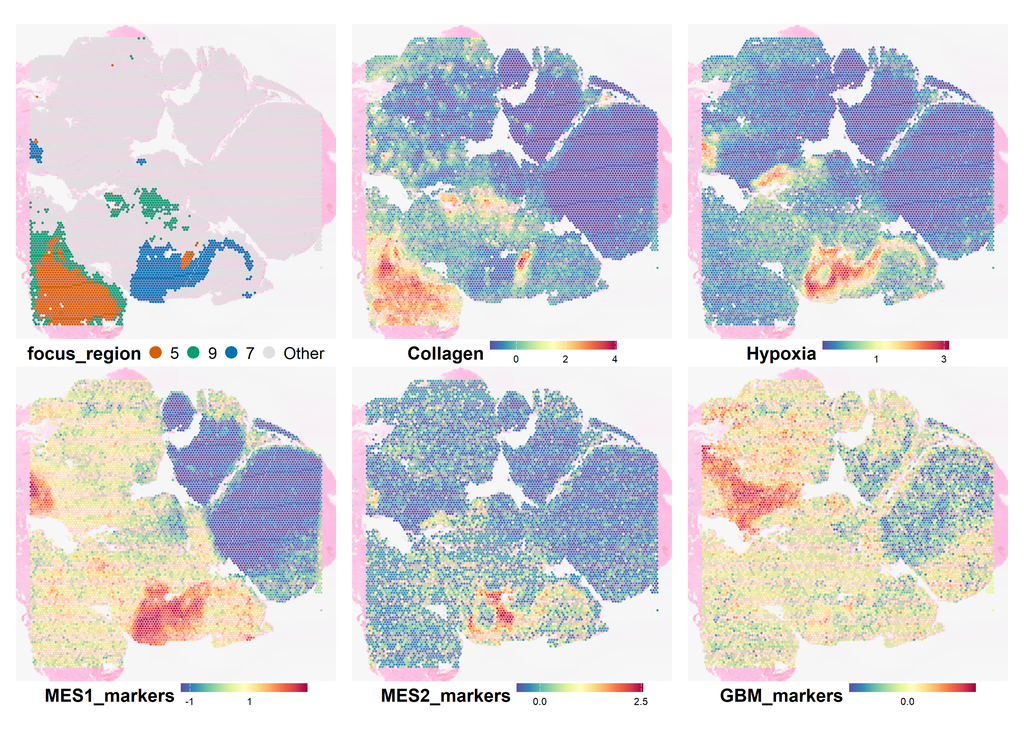

```r
## Not a must, just making the graphs more readble
p_clusters <- p_clusters +
  ggplot2::guides(
    fill = ggplot2::guide_legend(
      override.aes = list(size = 6, alpha = 1)
    )
  )

score_maps <- lapply(score_maps, function(p) {
  fill_scale <- p$scales$get_scales("fill")
  fill_scale$breaks <- scales::breaks_extended(n = 3)

  p + ggplot2::guides(
    fill = ggplot2::guide_colourbar(
      direction = "horizontal",
      theme = ggplot2::theme(
        legend.key.width = grid::unit(44, "mm"),
        legend.key.height = grid::unit(3, "mm"),
        legend.text = ggplot2::element_text(size = 10)
      )
    )
  )
})

## Plotting

p_spatial <- wrap_plots(
  c(list(p_clusters), score_maps),
  ncol = 3,
  nrow = 2,
  guides = "keep"
) & ggplot2::theme(
  plot.margin = ggplot2::margin(t = 1, r = 8, b = 1, l = 8, unit = "pt"),
  legend.position = "bottom",
  legend.box.spacing = grid::unit(2, "pt"),
  legend.margin = ggplot2::margin(0, 0, 0, 0),
  legend.text = ggplot2::element_text(size = 16),
  legend.title = ggplot2::element_text(size = 18, face = "bold")
)

p_spatial
```

## Comparing Clusters highly expression MBP

```r
avg_expr <- AverageExpression(
  GBM,
  assays = "SCT",
  group.by = "seurat_clusters",
  layer = "scale.data"
)$SCT

clusters_to_compare <- c(
  "g1", "g10", "g14", "g17",
  "g8", "g12", "g16"
)

avg_expr_subset <- as.matrix(
  avg_expr[, clusters_to_compare, drop = FALSE]
)

cor_matrix <- cor(
  avg_expr_subset,
  method = "spearman"
)

round(cor_matrix, 3)
```

```
        g1    g10    g14   g17     g8   g12    g16
g1   1.000  0.224  0.944 0.440  0.374 0.457 -0.194
g10  0.224  1.000  0.229 0.299 -0.090 0.431  0.587
g14  0.944  0.229  1.000 0.424  0.376 0.434 -0.202
g17  0.440  0.299  0.424 1.000  0.320 0.277  0.065
g8   0.374 -0.090  0.376 0.320  1.000 0.210 -0.312
g12  0.457  0.431  0.434 0.277  0.210 1.000  0.407
g16 -0.194  0.587 -0.202 0.065 -0.312 0.407  1.000
```

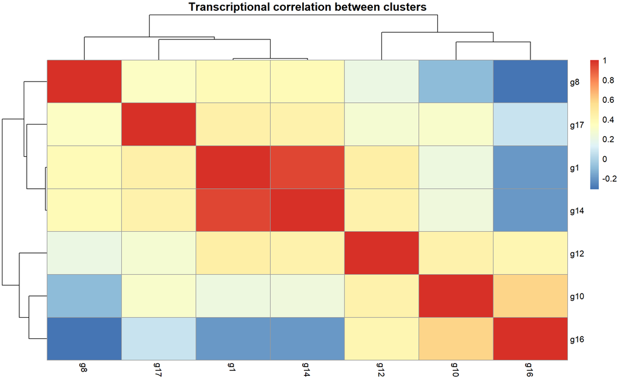

```r
library(pheatmap)

pheatmap(
  cor_matrix,
  cluster_rows = TRUE,
  cluster_cols = TRUE,
  main = "Transcriptional correlation between clusters"
)
```

```r
cor_pairs <- as.data.frame(as.table(cor_matrix))

cor_pairs <- cor_pairs %>%
  filter(Var1 != Var2) %>%
  mutate(
    pair = paste(
      pmin(as.character(Var1), as.character(Var2)),
      pmax(as.character(Var1), as.character(Var2)),
      sep = " vs "
    )
  ) %>%
  distinct(pair, .keep_all = TRUE) %>%
  arrange(desc(Freq))

cor_pairs
```

| Var1 | Var2 | Freq | pair |
| --- | --- | --- | --- |
| g14 | g1 | 0.94376386 | g1 vs g14 |
| g16 | g10 | 0.58682826 | g10 vs g16 |
| g12 | g1 | 0.45725566 | g1 vs g12 |
| g17 | g1 | 0.43991782 | g1 vs g17 |
| g12 | g14 | 0.43404108 | g12 vs g14 |
| g12 | g10 | 0.43060405 | g10 vs g12 |
| g17 | g14 | 0.42397366 | g14 vs g17 |
| g16 | g12 | 0.40749440 | g12 vs g16 |
| g8 | g14 | 0.37597663 | g14 vs g8 |
| g8 | g1 | 0.37352477 | g1 vs g8 |

[output cut: 11 more lines]

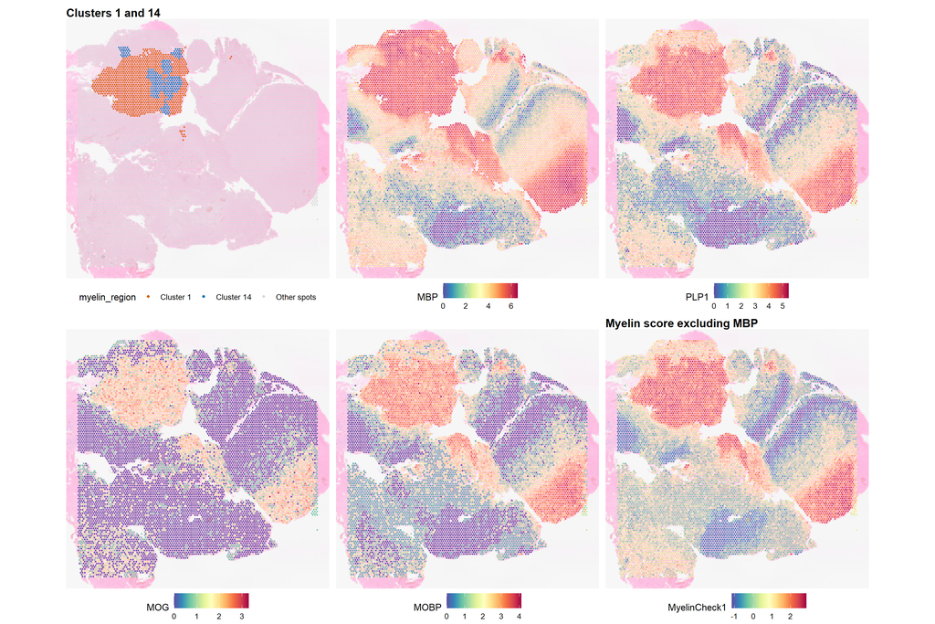

```r
library(Seurat)
library(dplyr)
library(ggplot2)
library(patchwork)

gbm_myelin <- GBM
DefaultAssay(gbm_myelin) <- "SCT"

support_genes <- c("PLP1", "MOG", "MOBP")
genes <- c("MBP", support_genes)

missing_genes <- setdiff(genes, rownames(gbm_myelin[["SCT"]]))
if (length(missing_genes) > 0) {
  stop("Genes missing from the SCT assay: ", paste(missing_genes, collapse = ", "))
}

cluster_ids <- as.character(gbm_myelin$seurat_clusters)
gbm_myelin$myelin_region <- factor(
  ifelse(cluster_ids %in% c("1", "14"), paste("Cluster", cluster_ids), "Other spots"),
  levels = c("Cluster 1", "Cluster 14", "Other spots")
)

gbm_myelin <- AddModuleScore(
  gbm_myelin,
  features = list(support_genes),
  assay = "SCT",
  name = "MyelinCheck",
  seed = 42
)

image_id <- Images(gbm_myelin)[1]

p_clusters <- SpatialDimPlot(
  gbm_myelin,
  group.by = "myelin_region",
  images = image_id,
  image.scale = "lowres",
  cols = c(
    "Cluster 1" = "#D55E00",
    "Cluster 14" = "#0072B2",
    "Other spots" = "#D9D9D9"
  ),
  pt.size.factor = 2.5,
  image.alpha = 0.55,
  combine = FALSE
)[[1]] + ggtitle("Clusters 1 and 14")

marker_maps <- SpatialFeaturePlot(
  gbm_myelin,
  features = c(genes, "MyelinCheck1"),
  slot = "data",
  images = image_id,
  image.scale = "lowres",
  pt.size.factor = 2.5,
  image.alpha = 0.55,
  keep.scale = "feature",
  combine = FALSE
)

score_panel <- length(marker_maps)
marker_maps[[score_panel]] <- marker_maps[[score_panel]] +
  ggtitle("Myelin score excluding MBP")

p_myelin <- wrap_plots(c(list(p_clusters), marker_maps), ncol = 3) &
  theme(
    plot.margin = margin(2, 4, 2, 4),
    legend.position = "bottom",
    plot.title = element_text(size = 13, face = "bold")
  )

p_myelin
```

```r
spot_data <- FetchData(
  gbm_myelin,
  vars = c("myelin_region", genes, "MyelinCheck1"),
  layer = "data"
)

spot_data %>%
  group_by(myelin_region) %>%
  summarise(
    spots = n(),
    across(all_of(genes), mean, .names = "mean_{.col}"),
    median_myelin_score = median(MyelinCheck1),
    .groups = "drop"
  )
```

| myelin_region | spots | mean_MBP | mean_PLP1 | mean_MOG | mean_MOBP | median_myelin_score |
| --- | --- | --- | --- | --- | --- | --- |
| Cluster 1 | 969 | 5.496520 | 4.420018 | 1.8037202 | 2.963050 | 2.1170766 |
| Cluster 14 | 272 | 5.442496 | 4.386883 | 1.7914450 | 2.936575 | 2.1202915 |
| Other spots | 9637 | 3.077577 | 1.917730 | 0.4151402 | 1.046296 | 0.1013383 |

```r
mbp_spots <- FetchData(
  gbm_myelin,
  vars = c("seurat_clusters", "MBP", "MyelinCheck1", "nCount_Spatial"),
  layer = "data"
)

focus <- c("1", "14")
mbp_cutoff <- quantile(mbp_spots$MBP, 0.80, names = FALSE)

mbp_spots$cluster <- as.character(mbp_spots$seurat_clusters)
mbp_spots$mbp_high <- mbp_spots$MBP > 0 & mbp_spots$MBP >= mbp_cutoff

mbp_summary <- mbp_spots %>%
  group_by(cluster) %>%
  summarise(
    spots = n(),
    high_spots = sum(mbp_high),
    pct_high = round(100 * mean(mbp_high), 1),
    median_MBP_high = median(MBP[mbp_high]),
    median_myelin_high = median(MyelinCheck1[mbp_high]),
    median_UMIs_high = median(nCount_Spatial[mbp_high]),
    .groups = "drop"
  ) %>%
  arrange(desc(pct_high))

print(mbp_summary, n = Inf)
```

```
# A tibble: 21 × 7
   cluster spots high_spots pct_high median_MBP_high median_myelin_high median_UMIs_high
   <chr>   <int>      <int>    <dbl>           <dbl>              <dbl>            <dbl>
 1 12        478        456     95.4            5.68              2.13             8796.
 2 1         969        891     92              5.52              2.13            15237
 3 14        272        236     86.8            5.45              2.14            13759
 4 8         616        343     55.7            5.58              1.21             2376
 5 16        214         72     33.6            5.39              1.79            11532.
 6 10        557        152     27.3            5.49              1.93             6103
 7 17        124         13     10.5            5.32              1.66             7006
 8 18        112          3      2.7            5.62              0.822            3174
 9 19         91          2      2.2            5.27              0.953            4998
10 4         757          5      0.7            5.48              1.29            12384
11 0        1262          8      0.6            5.35              1.04             3468.
12 13        307          1      0.3            5.64              0.944            3232
13 5         725          1      0.1            5.33              1.43             2831
14 11        482          0      0             NA                NA                  NA
15 15        255          0      0             NA                NA                  NA
16 2         902          0      0             NA                NA                  NA
17 20         63          0      0             NA                NA                  NA
18 3         795          0      0             NA                NA                  NA
19 6         677          0      0             NA                NA                  NA
20 7         649          0      0             NA                NA                  NA
21 9         571          0      0             NA                NA                  NA
```

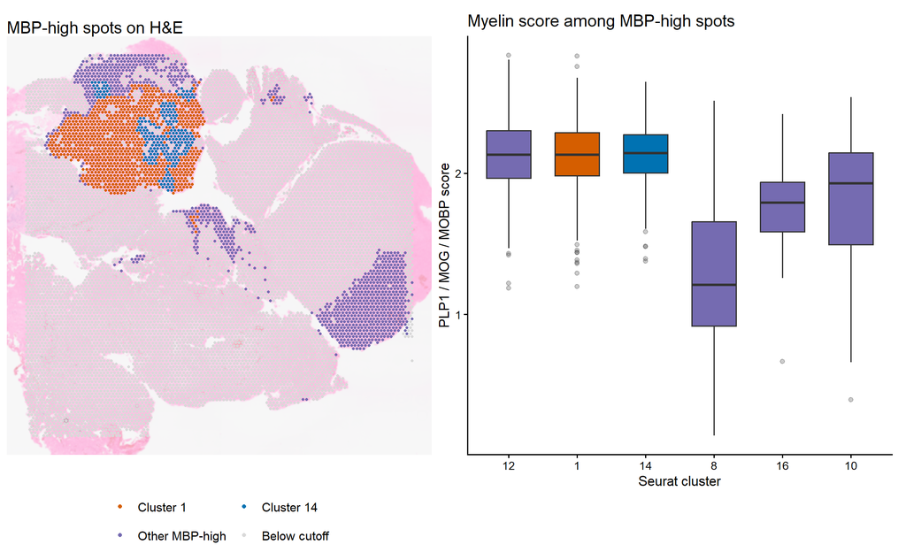

```r
# Mapping high spots in clusters 1, 14 and the rest of the section.
mbp_colours <- c(
  "Cluster 1" = "#D55E00",
  "Cluster 14" = "#0072B2",
  "Other MBP-high" = "#756BB1",
  "Below cutoff" = "#D9D9D9"
)

mbp_spots$mbp_region <- factor(
  case_when(
    !mbp_spots$mbp_high ~ "Below cutoff",
    mbp_spots$cluster %in% focus ~ paste("Cluster", mbp_spots$cluster),
    TRUE ~ "Other MBP-high"
  ),
  levels = names(mbp_colours)
)

gbm_mbp_map <- AddMetaData(gbm_myelin, metadata = mbp_spots["mbp_region"])

p_mbp_map <- SpatialDimPlot(
  gbm_mbp_map,
  group.by = "mbp_region",
  images = Images(gbm_mbp_map)[1],
  image.scale = "lowres",
  cols = mbp_colours,
  pt.size.factor = 2.5,
  image.alpha = 0.55,
  combine = FALSE
)[[1]] +
  labs(title = "MBP-high spots on H&E", fill = NULL) +
  guides(fill = guide_legend(nrow = 2, byrow = TRUE)) +
  theme(
    legend.position = "bottom",
    legend.text = element_text(size = 10),
    legend.margin = margin(0, 0, 0, 0)
  )

# Comparing the score in clusters with enough high spots to show a distribution.
plot_clusters <- mbp_summary %>%
  filter(high_spots >= 20 | cluster %in% focus) %>%
  pull(cluster)

p_mbp_compare <- mbp_spots %>%
  filter(mbp_high, cluster %in% plot_clusters) %>%
  mutate(cluster = factor(cluster, levels = plot_clusters)) %>%
  ggplot(aes(cluster, MyelinCheck1, fill = mbp_region)) +
  geom_boxplot(width = 0.65, outlier.alpha = 0.25) +
  scale_fill_manual(values = mbp_colours, guide = "none") +
  labs(
    title = "Myelin score among MBP-high spots",
    x = "Seurat cluster",
    y = "PLP1 / MOG / MOBP score"
  ) +
  theme_classic()

p_mbp_map + p_mbp_compare
```

From the looks of it, cluster 12 demonstrates particularly similar Myelin scores among MBP-high spots and interestingly, at a fairly further region than cluster 1 and 14.

Posteriorly I will investigate what is the major difference between these two areas that drive the correlation score between them to be

0.45725566 (g1 vs g12) 0.43404108 (g12 vs g14)

Particularly when compared to the similarity if g1 vs g14

0.94376386 (g1 vs g14)

```r
library(dplyr)

clusters <- c("1", "14", "12")
myelin_genes <- c("MBP", "PLP1", "MOG", "MOBP")

sct_residuals <- SeuratObject::LayerData(
  gbm_myelin, assay = "SCT", layer = "scale.data"
)

cluster_by_spot <- setNames(
  as.character(gbm_myelin$seurat_clusters),
  colnames(gbm_myelin)
)

spots_by_cluster <- split(
  colnames(sct_residuals),
  factor(cluster_by_spot[colnames(sct_residuals)], levels = clusters)
)

mbp_high_spots <- rownames(mbp_spots)[which(mbp_spots$mbp_high)]

data.frame(
  cluster = clusters,
  all_spots = lengths(spots_by_cluster),
  MBP_high_spots = lengths(lapply(spots_by_cluster, intersect, y = mbp_high_spots))
)
```

|  | cluster | all_spots | MBP_high_spots |
| --- | --- | --- | --- |
| 1 | 1 | 969 | 891 |
| 14 | 14 | 272 | 236 |
| 12 | 12 | 478 | 456 |

```r
mean_profiles <- function(barcodes) {
  profiles <- vapply(
    spots_by_cluster,
    function(spots) {
      selected <- intersect(spots, barcodes)
      Matrix::rowMeans(sct_residuals[, selected, drop = FALSE])
    },
    numeric(nrow(sct_residuals))
  )
  rownames(profiles) <- rownames(sct_residuals)
  profiles
}

all_profiles <- mean_profiles(colnames(sct_residuals))
high_profiles <- mean_profiles(mbp_high_spots)
held_out <- !rownames(all_profiles) %in% myelin_genes

pairwise_rho <- function(profiles) {
  rho <- cor(profiles, method = "spearman", use = "pairwise.complete.obs")
  c(
    "12 vs 1" = rho["12", "1"],
    "12 vs 14" = rho["12", "14"],
    "1 vs 14" = rho["1", "14"]
  )
}

round(rbind(
  "All spots" = pairwise_rho(all_profiles),
  "All spots excluding myelin markers" = pairwise_rho(all_profiles[held_out, ]),
  "MBP-high spots" = pairwise_rho(high_profiles),
  "MBP-high spots excluding myelin markers" = pairwise_rho(high_profiles[held_out, ])
), 3)
```

```
                                        12 vs 1 12 vs 14 1 vs 14
All spots                                 0.457    0.434   0.944
All spots excluding myelin markers        0.455    0.432   0.944
MBP-high spots                            0.493    0.468   0.939
MBP-high spots excluding myelin markers   0.491    0.465   0.939
```

```r
# Find shared positive residuals and genes ranked differently in cluster 12.
gene_profiles <- tibble::tibble(
  gene = rownames(all_profiles),
  C1 = all_profiles[, "1"],
  C14 = all_profiles[, "14"],
  C12 = all_profiles[, "12"],
  shared_residual = pmin(C1, C14, C12),
  rank_shift_vs_1 = rank(C12) - rank(C1),
  rank_shift_vs_14 = rank(C12) - rank(C14)
)

shared_genes <- gene_profiles %>%
  filter(shared_residual > 0) %>%
  slice_max(shared_residual, n = 8, with_ties = FALSE) %>%
  select(gene, C1, C14, C12)

shifted_12 <- gene_profiles %>%
  filter(rank_shift_vs_1 * rank_shift_vs_14 > 0) %>%
  mutate(rank_shift = pmin(abs(rank_shift_vs_1), abs(rank_shift_vs_14))) %>%
  slice_max(rank_shift, n = 10, with_ties = FALSE) %>%
  select(gene, C1, C14, C12, rank_shift_vs_1, rank_shift_vs_14)

shared_genes
```

| gene | C1 | C14 | C12 |
| --- | --- | --- | --- |
| PLP1 | 9.820366 | 9.302750 | 9.036538 |
| MBP | 6.455420 | 5.986841 | 8.418800 |
| MOBP | 5.149794 | 5.004131 | 6.675297 |
| CARNS1 | 4.121137 | 3.737067 | 3.880890 |
| CNP | 3.995665 | 3.699561 | 4.792416 |
| TMEM144 | 3.704167 | 3.476139 | 4.027070 |
| CLDND1 | 3.803625 | 3.888989 | 3.473692 |
| ERMN | 3.790241 | 3.470763 | 4.530164 |

```r
shifted_12
```

| gene | C1 | C14 | C12 | rank_shift_vs_1 | rank_shift_vs_14 |
| --- | --- | --- | --- | --- | --- |
| STAB1 | 3.775834 | 3.855923 | -1.0602476 | -2950 | -2949 |
| CD163 | 2.643443 | 3.121113 | -1.6678239 | -2948 | -2961 |
| CHI3L2 | 3.070306 | 2.854283 | -1.1255423 | -2946 | -2930 |
| PLTP | 2.640767 | 2.975190 | -1.1105233 | -2922 | -2931 |
| KIF5A | -1.556623 | -1.533512 | 1.8019306 | 2914 | 2915 |
| C1QA | 3.557624 | 3.545940 | -0.8151792 | -2904 | -2903 |
| CD14 | 2.513616 | 3.094833 | -0.9716438 | -2901 | -2920 |
| VSIG4 | 2.884711 | 3.196468 | -0.8308524 | -2891 | -2895 |
| MS4A6A | 3.669975 | 3.897608 | -0.7766367 | -2890 | -2893 |
| C3 | 2.424955 | 2.438309 | -0.8699562 | -2878 | -2875 |

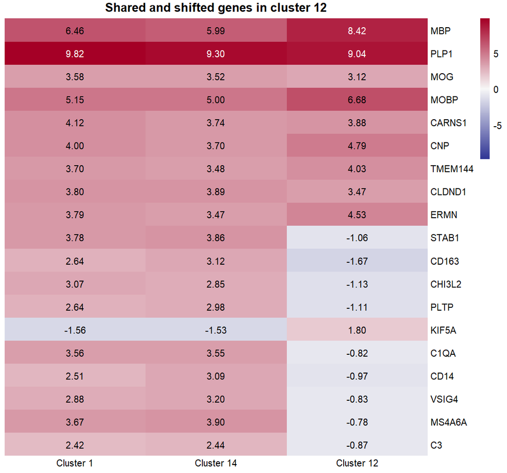

```r
p_cluster_12 <- pheatmap::pheatmap(
  heatmap_values,
  cluster_rows = FALSE,
  cluster_cols = FALSE,
  labels_col = paste("Cluster", clusters),
  angle_col = "0",
  color = colorRampPalette(c("#313695", "#F7F7F7", "#A50026"))(101),
  breaks = seq(-colour_limit, colour_limit, length.out = 102),
  border_color = NA,
  display_numbers = TRUE,
  number_format = "%.2f",
  fontsize_number = 10,
  number_color = number_colours,
  main = "Shared and shifted genes in cluster 12"
)
```

```r
ggplot2::ggsave(
  filename = "GBM_Cluster_12_Comparison_Numbered.png",
  plot = p_cluster_12$gtable,
  width = 7.5,
  height = 7,
  units = "in",
  dpi = 300,
  bg = "white"
)
```

## Conclusions between cluster 1, 12 and 14

Cluster 1 and 14 present very similar genetic composition particularly within their predominant set of Myelin score.

Even though cluster 12 presents a fairly similar Myelin score within the MBP predominant spots of this tissue, this cluster demonstrates a shift towards lower genetic expression of genes that present higher SCT transformed RNA expression within cluster 1 and 14.

Interestingly a majority of cells within cluster 12 are actively expression KIF5A a marker that has previously been associated to correlate negatively with tumour grade, with lower levels of expression being highly present in GBM tumour cells (Joyce & Lindsay, 2024).

This could be a good explanation on why these clusters present such high similarity but also, somewhat dissimilar, with a high chance of a GBM tumour slowly forming within cluster 1 and 14, while cluster 12 cells demonstrate to be closely within healthy states.

Another major factor that may indicate this is the highly expression of CD14 and CD163 cells within cluster 1 and 14, indicating direct activity of immune system in this region and possibly part of a forming GBM.

## Comparison of clusters 1, 12 and 14

The comparison began with spots classified as MBP-high using the section-wide 80th percentile. Within this subset, median module scores for PLP1, MOG and MOBP were 2.13 in cluster 1, 2.14 in cluster 14 and 2.13 in cluster 12. The three clusters therefore shared a similar myelin-associated signal.

To compare their broader expression profiles, genes were ranked by their mean SCT residual within each cluster. Spearman correlations were calculated using all spots and then recalculated within the MBP-high subset.

The relative similarity of the clusters persisted after removing MBP, PLP1, MOG and MOBP from the correlation. The agreement between clusters 1 and 14 therefore extended beyond the selected myelin markers.

The gene-level comparison showed lower mean SCT residuals for CD14, CD163, C1QA and VSIG4 in cluster 12. For example, the CD163 residual was −1.67 in cluster 12, compared with +2.64 in cluster 1 and +3.12 in cluster 14. KIF5A showed the reverse pattern, with a mean residual of +1.80 in cluster 12 and negative values in both other clusters.

# Final Conclusions

## Collagen enrichment in clusters 5 and 9 and hypoxia in cluster 7

Clusters 5 and 9 shared elevated expression of COL1A1, COL1A2 and COL3A1. Their cluster-average SCT profiles showed moderate agreement in gene ranks (Spearman ρ = 0.571). Within that shared collagen programme, COL6A3 was detected more frequently in cluster 5 than in cluster 9 (88.7% versus 45.7% of spots).

The hypoxia-associated module score overlapped cluster 7. The marker analysis supported this spatial pattern. CA9 was detected in 80.3% of cluster 7 spots and 7.9% of spots outside the cluster. The corresponding figures for HILPDA were 98.0% and 28.3%.

The collagen-associated expression is consistent with extracellular matrix remodelling. Published spatial studies have described collagen-rich perivascular regions in recurrent GBM and linked hypoxia-associated expression to tissue organisation around necrotic cores (Onubogu et al., 2024; Greenwald et al., 2024). Comparing the score maps with the matched H&E would help establish how the collagen-enriched regions and the cluster 7 hypoxia signal are positioned relative to vessels and necrotic borders in this section.

## Myelin-rich regions in clusters 1 and 14 compared with cluster 12

The higher residuals for myeloid and complement-associated genes in clusters 1 and 14 suggest a stronger myeloid-associated RNA signal in those regions (Miller et al., 2025). The higher KIF5A residual in cluster 12 is compatible with a greater neuronal RNA contribution given the gene’s role in axonal transport. Joyce and Lindsay (2024) reported an inverse association between KIF5A expression and glioma grade in a separate cohort analysis.

These spot-level differences may reflect variation in cell composition, transcriptional state or both within this GBM section. Matched histology and tumour-associated copy-number profiles would help assess whether the myelin-rich regions differ in local tumour infiltration.

# References

· Joyce, L.J. and Lindsay, A.J. (2024) ‘A systematic computational analysis of the endosomal recycling pathway in glioblastoma’, Biochemistry and Biophysics Reports, 38, p. 101700. https://pubmed.ncbi.nlm.nih.gov/38638676/

· Miller, T.E. et al. (2025) ‘Programs, origins and immunomodulatory functions of myeloid cells in glioma’, Nature, 640(8060), pp. 1072–1082. https://www.nature.com/articles/s41586-025-08633-8

· Greenwald, A.C. et al. (2024). ‘Integrative spatial analysis reveals a multi-layered organization of glioblastoma’. Cell, 187(10), pp. 2485–2501.e26. https://doi.org/10.1016/j.cell.2024.03.029

· Onubogu, U. et al. (2024). ‘Spatial analysis of recurrent glioblastoma reveals perivascular niche organization’. JCI Insight, 9(12), https://insight.jci.org/articles/view/179853